# Portland Crashes

Thomas Sato

2022-10-12

This dataset is from RLIS, and it contains 321,829 car crashes in the Portland Metro area from 2007 to 2020.

Reading in the data:

```r
library(tidyverse)
crashes <- read_csv("Crashes.csv")
orpop <- read_csv("https://raw.githubusercontent.com/thomascsato/Portland-Metro-Area-Car-Crashes/main/Oregon%20Cities%20Population.csv", col_names = c("Rank", "City", "Population"))
Streets <- read_csv("https://raw.githubusercontent.com/thomascsato/Portland-Metro-Area-Car-Crashes/main/Streets.csv")
```

# Distributions

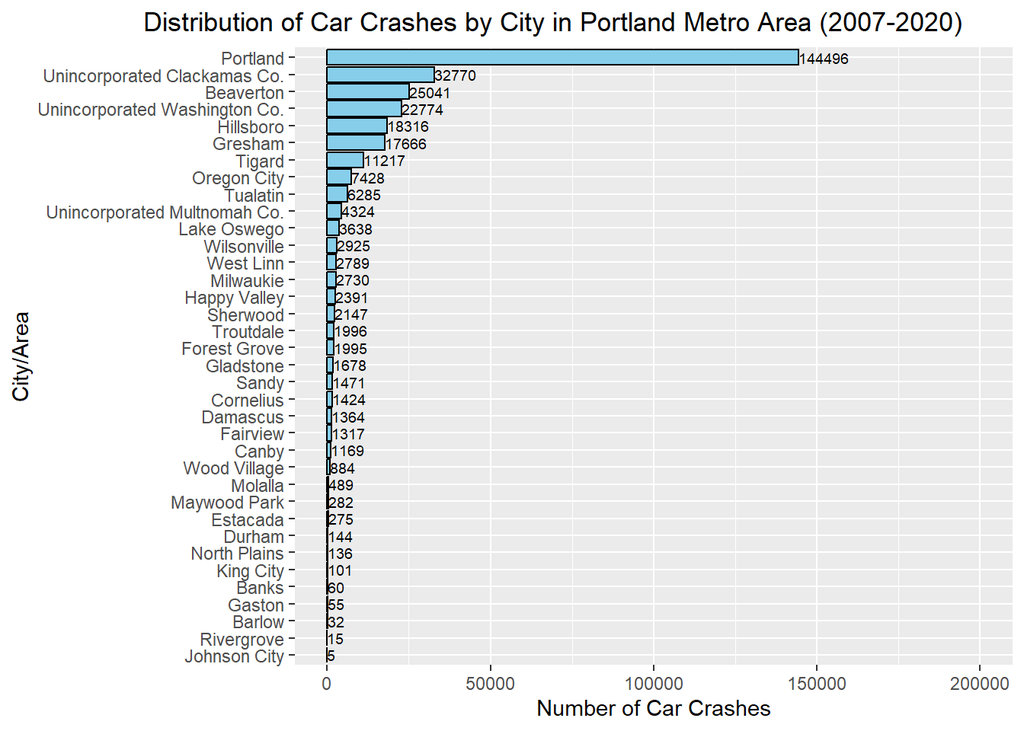

```r
ggplot(crashes, aes(x = fct_rev(fct_infreq(GIS_JURIS)))) +
  geom_bar(fill = "skyblue", color = "black") +
  geom_text(aes(label = ..count..), stat = "count", size = 2.5, hjust = 0) +
  coord_flip() +
  ggtitle("Distribution of Car Crashes by City in Portland Metro Area (2007-2020)") +
  theme(plot.title = element_text(hjust = 1.5)) +
  ylab("Number of Car Crashes") +
  xlab("City/Area") +
  scale_y_continuous(limits = c(0, 200000))
```

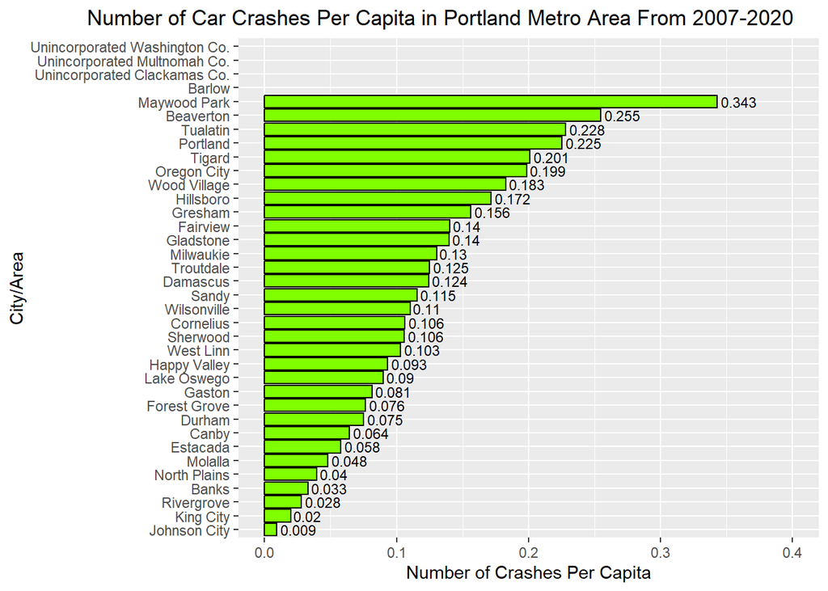

```r
ncrash <- crashes %>%
  group_by(GIS_JURIS) %>%
  summarize(n = n())

# Fairview city population data was inaccurate
orpop[which(orpop$City == "Fairview"), 3] <- 9382

percap <- left_join(ncrash, orpop, by = c("GIS_JURIS" = "City")) %>%
  mutate(cpercap = n / Population) %>%
  arrange(desc(cpercap))

ggplot(percap, aes(fct_reorder(GIS_JURIS, cpercap), cpercap)) +
  geom_col(fill = "chartreuse", color = "black") +
  coord_flip() +
  xlab("City/Area") +
  ylab("Number of Crashes Per Capita") +
  ggtitle("Number of Car Crashes Per Capita in Portland Metro Area From 2007-2020") +
  scale_y_continuous(limits = c(0, 0.4)) +
  theme(plot.title = element_text(hjust = 1.2)) +
  geom_text(aes(label = round(cpercap, 3)), size = 3, hjust = -0.1)
```

# Streets Analysis

Initial Data Transformation

```r
# Getting the sum length of all the streets because the vector shapefile has every street in segments
streetlen <- Streets %>%
  group_by(PREFIX, STREETNAME, FTYPE) %>%
  summarize(stlength = sum(LENGTH)) %>%
  # Ifelse statement used in order to not have NAs in some full street names
  mutate(FullStName = ifelse(is.na(PREFIX), paste(STREETNAME, FTYPE, sep = " "),
                             paste(PREFIX, STREETNAME, FTYPE, sep = " ")))
# Dataset containing the number of crashes per street
crashesperstreet <- crashes %>%
  group_by(ST_FULL_NM) %>%
  summarize(n = n()) %>%
  arrange(desc(n))

# Joins together the dataset in order to have a variable for crashes per foot of street
crashesperft <- left_join(crashesperstreet, streetlen, by = c("ST_FULL_NM" = "FullStName")) %>%
  mutate(crashes_per_foot = n / stlength) %>%
  arrange(desc(crashes_per_foot)) %>%
  # Ranking for every street in terms of crashes per foot
  mutate(index = 1:nrow(crashesperstreet)) %>%
  # We filter out Kelly Ave because it is an outlier - Experience says that there is no reason to think that Kelly Ave has that high of a ratio of crashes per foot of street, so I assume there must be an error in data entry or something like that
  filter(ST_FULL_NM != "SW KELLY AVE")
```

## Visualizations Relating to the Number of Crashes per Foot of Street

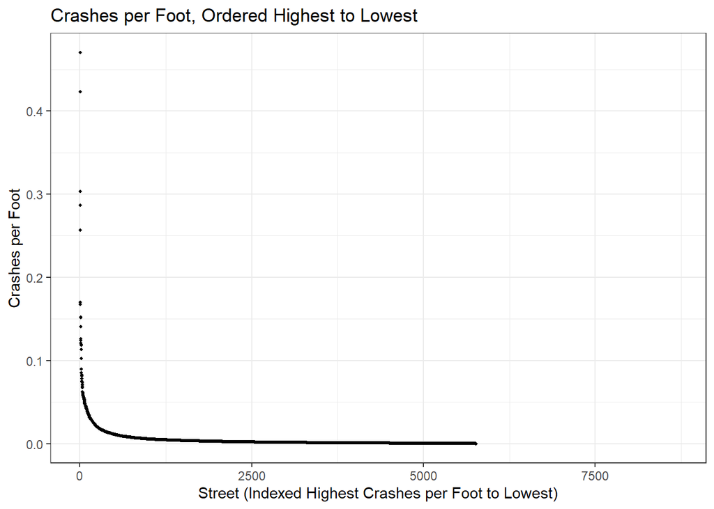

```r
# Graph of how the number of crashes per foot decreases in order from greatest to least
ggplot(crashesperft, aes(x = index, y = crashes_per_foot)) +
  geom_point(size = 0.75) +
  theme_bw() +
  ggtitle("Crashes per Foot, Ordered Highest to Lowest") +
  xlab("Street (Indexed Highest Crashes per Foot to Lowest)") +
  ylab("Crashes per Foot")
```

### Basic Modeling

```r
# Attempting to create a transformation (1 / X) in order to create a linear regression model
inversecrashesmodel <- lm(crashes_per_foot ~ I(1/(index)), data = crashesperft)
summary(inversecrashesmodel)
```

```
##
## Call:
## lm(formula = crashes_per_foot ~ I(1/(index)), data = crashesperft)
##
## Residuals:
##       Min        1Q    Median        3Q       Max
## -0.183091 -0.002556 -0.001838  0.000008  0.046788
##
## Coefficients:
##               Estimate Std. Error t value Pr(>|t|)
## (Intercept)  3.018e-03  7.915e-05   38.13   <2e-16 ***
## I(1/(index)) 1.301e+00  7.482e-03  173.92   <2e-16 ***
## ---
## Signif. codes:  0 '***' 0.001 '**' 0.01 '*' 0.05 '.' 0.1 ' ' 1
##
## Residual standard error: 0.005952 on 5759 degrees of freedom
##   (2915 observations deleted due to missingness)
## Multiple R-squared:  0.8401, Adjusted R-squared:   0.84
## F-statistic: 3.025e+04 on 1 and 5759 DF,  p-value: < 2.2e-16
```

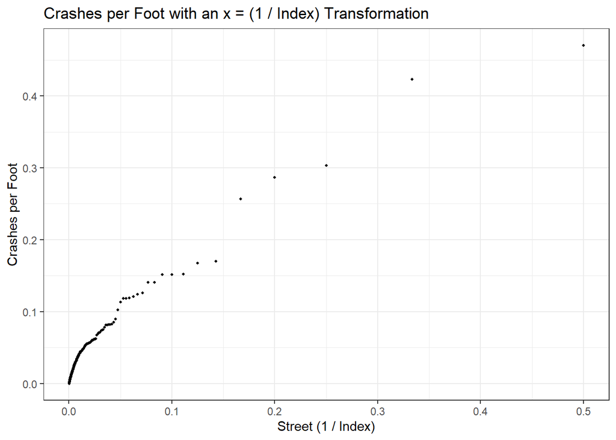

```r
# Visualizing the transformation
ggplot(crashesperft, aes(x = (1/index), y = crashes_per_foot)) +
  geom_point(size = 0.75) +
  theme_bw() +
  ggtitle("Crashes per Foot with an x = (1 / Index) Transformation") +
  xlab("Street (1 / Index)") +
  ylab("Crashes per Foot")
```

### Playing with R-squared

I noticed that the R-squared value of 0.84 was pretty good, but if I played around with the transformation a little bit, I was able to increase the R-squared value.

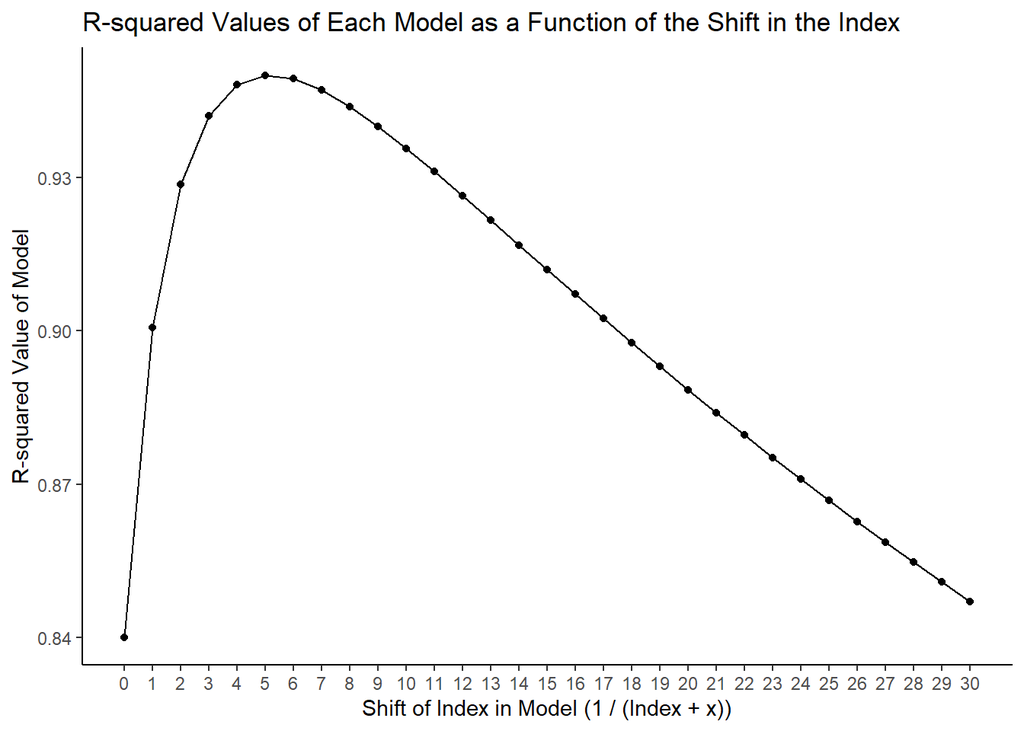

```r
# This will make a vector of R-squared values of
rsqvector <- c()
for(i in 0:30) {
  rsq <- summary(lm(crashes_per_foot ~ I(1/(index + i)), data = crashesperft))$r.squared
  rsqvector <- append(rsqvector, rsq)
}

ggplot(data.frame(r2 = rsqvector, ind = 0:30), aes(x = ind, y = r2)) +
  geom_point() +
  geom_line() +
  scale_x_continuous(breaks = 0:30) +
  theme_classic() +
  ggtitle("R-squared Values of Each Model as a Function of the Shift in the Index") +
  xlab("Shift of Index in Model (1 / (Index + x))") +
  ylab("R-squared Value of Model")
```

```r
max(rsqvector)
```

```
## [1] 0.9500657
```

```r
which.max(rsqvector) - 1
```

```
## [1] 5
```

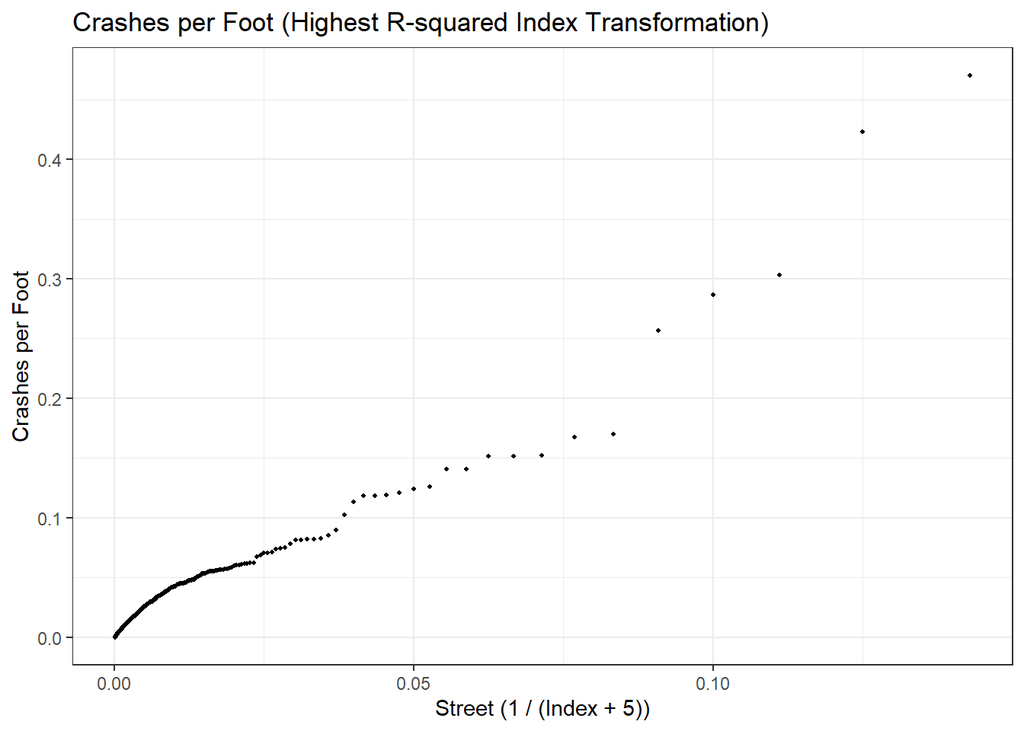

```r
ggplot(crashesperft, aes(x = (1/(index + 5)), y = crashes_per_foot)) +
  geom_point(size = 0.75) +
  theme_bw() +
  ggtitle("Crashes per Foot (Highest R-squared Index Transformation)") +
  xlab("Street (1 / (Index + 5))") +
  ylab("Crashes per Foot")
```

Noticing the interesting geometry of the shift of index in the model and the R-squared value of the model. Honestly, I have no idea what sort of mathematics causes these shapes to be so geometric, or why it is 5 that maximizes the R-squared value at 0.950065.

```r
maxrsq <- lm(crashes_per_foot ~ I(1/(index + 5)), data = crashesperft)
summary(maxrsq)
```

```
##
## Call:
## lm(formula = crashes_per_foot ~ I(1/(index + 5)), data = crashesperft)
##
## Residuals:
##       Min        1Q    Median        3Q       Max
## -0.072369 -0.001386 -0.000865  0.000423  0.060815
##
## Coefficients:
##                   Estimate Std. Error t value Pr(>|t|)
## (Intercept)      1.477e-03  4.501e-05   32.81   <2e-16 ***
## I(1/(index + 5)) 2.887e+00  8.723e-03  331.02   <2e-16 ***
## ---
## Signif. codes:  0 '***' 0.001 '**' 0.01 '*' 0.05 '.' 0.1 ' ' 1
##
## Residual standard error: 0.003326 on 5759 degrees of freedom
##   (2915 observations deleted due to missingness)
## Multiple R-squared:  0.9501, Adjusted R-squared:  0.9501
## F-statistic: 1.096e+05 on 1 and 5759 DF,  p-value: < 2.2e-16
```

I kind of ran out of time for the project to play with the data a little bit more, which is a bit disappointing, because there is so much cool stuff in this dataset, but I think I will keep playing with it to discover anything else. I think the index transformation stuff is quite interesting. According to this model which may or may not be super accurate, if you gave me a ranking of a particular street compared to the others, I could predict how many crashes occur over the length of the street.